# 数据探索与研究1

2023-02-07

# 读入原始数据

## load useful packages

```r
# load the useful packages
library(dplyr)
library(plotly)
library(CBCgrps)
library(networkD3)

library(PerformanceAnalytics)

##randomForest 包的随机森林
library(randomForest)
```

## import the data and then have a look

```r
raw_data = read.csv("outputs/raw_data.csv", encoding="UTF-8")
raw_data[raw_data==""] = NA # convert the null values to NA
```

have a look of the structure of dataframe

```r
raw_data = raw_data[,1:78]
raw_data %>% dim()
```

```
## [1] 116  78
```

# 读入处理好的原始数据

```r
l_data_grpcop_glm = readRDS("outputs/l_dat_grpcop_glm.rds")
df_data_glm = l_data_grpcop_glm$df_data_glm
df_grpcop = l_data_grpcop_glm$df_grpcop
```

# 数据探索

## 第零阶段: 操作变量, 加入一些列

加入中性粒细胞绝对值/淋巴细胞绝对值

```r
df_细胞比例 = raw_data[, c("姓名", "中性粒细胞绝对值", "淋巴细胞绝对值", "中性粒细胞绝对值.1", "淋巴细胞绝对值.1" )]
df_细胞比例[, "中性粒.淋巴"] = df_细胞比例[, "中性粒细胞绝对值"]/df_细胞比例[, "淋巴细胞绝对值"]
df_细胞比例[, "中性粒.淋巴.1"] = df_细胞比例[, "中性粒细胞绝对值.1"]/df_细胞比例[, "淋巴细胞绝对值.1"]

df_细胞比例 %>% head()
```

```
##     姓名 中性粒细胞绝对值 淋巴细胞绝对值 中性粒细胞绝对值.1 淋巴细胞绝对值.1
## 1   谷巍             1.53           0.91               3.30             0.66
## 2 武艳丽             3.00           1.20               3.90             1.00
## 3   刘静             6.15           0.74               5.26             3.02
## 4 王依菡            13.63           8.12               5.26             3.02
## 5 李凤章             2.20           1.57               2.48             0.60
## 6 王习俭             0.13           0.40               2.70             0.65
##   中性粒.淋巴 中性粒.淋巴.1
## 1    1.681319      5.000000
## 2    2.500000      3.900000
## 3    8.310811      1.741722
## 4    1.678571      1.741722
## 5    1.401274      4.133333
## 6    0.325000      4.153846
```

```r
df_血红蛋白 = raw_data[, c("姓名", "血红蛋白", "血红蛋白.1")]
df_血红蛋白[, "血红蛋白变化值"] =  raw_data[, "血红蛋白.1"] - raw_data[, "血红蛋白"]
df_血红蛋白 %>% head()
```

```
##     姓名 血红蛋白 血红蛋白.1 血红蛋白变化值
## 1   谷巍      100        116             16
## 2 武艳丽      155        124            -31
## 3   刘静      120        121              1
## 4 王依菡      106        121             15
## 5 李凤章      100        116             16
## 6 王习俭       87        108             21
```

做成一个数据补充的表格, merge入用于单因素分析和回归的表格中

```r
# df_数据补充 = merge(df_血红蛋白, df_细胞比例)
df_grpcop = merge(df_血红蛋白, df_grpcop) %>% merge(df_细胞比例)
df_data_glm = merge(df_血红蛋白, df_data_glm) %>% merge(df_细胞比例)
```

## 第一阶段: 先考察原始数据的pattern和两两对应的图

每个变量都画分布图

```r
# 引入函数
source("exploration/plot_items_pattern.R")
```

```r
df_data_glm %>% dim()
```

```
## [1] 102  34
```

画一下数据分布

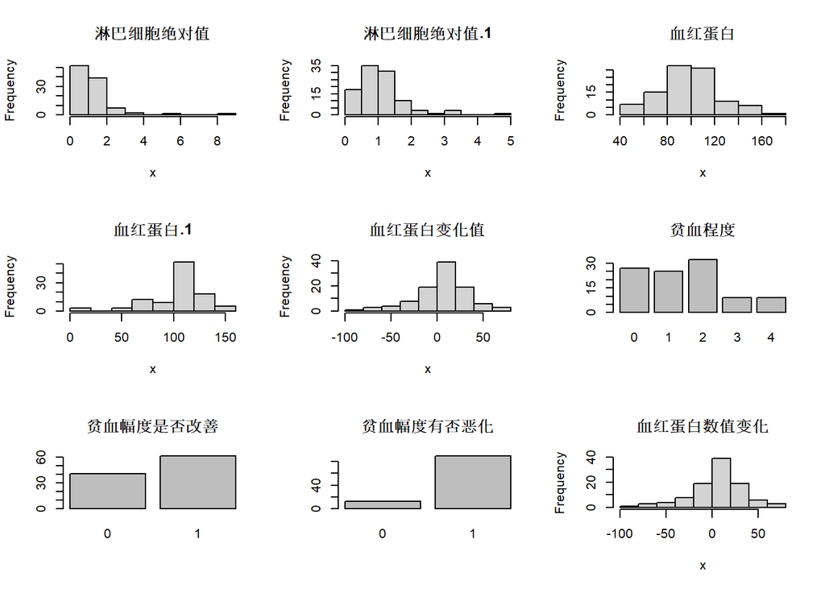

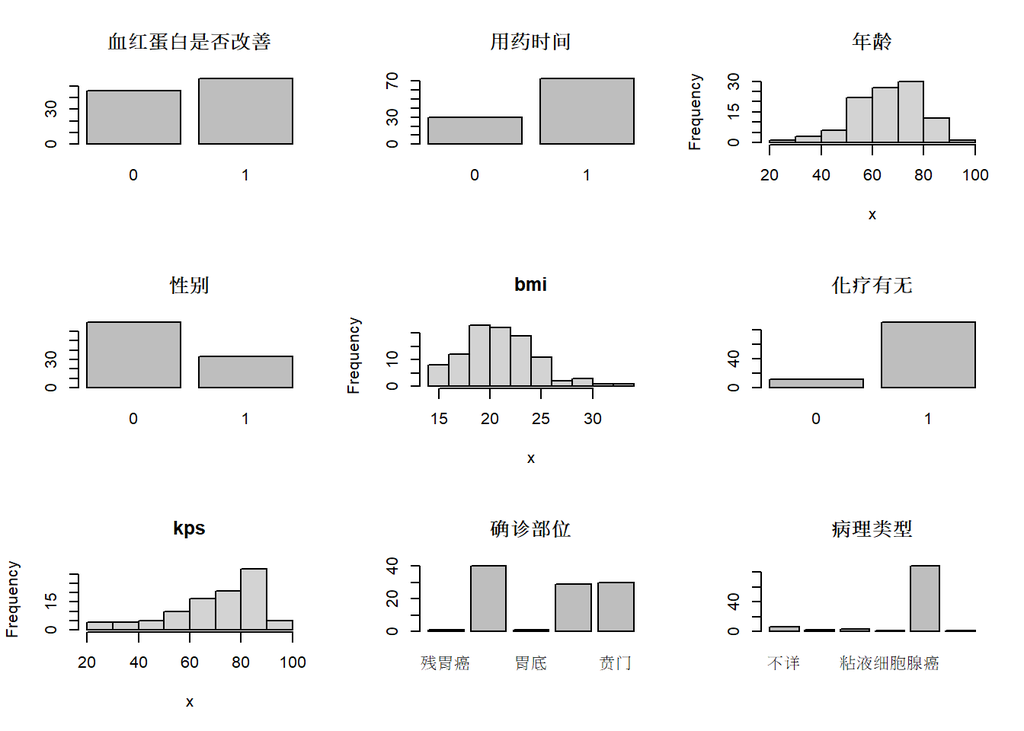

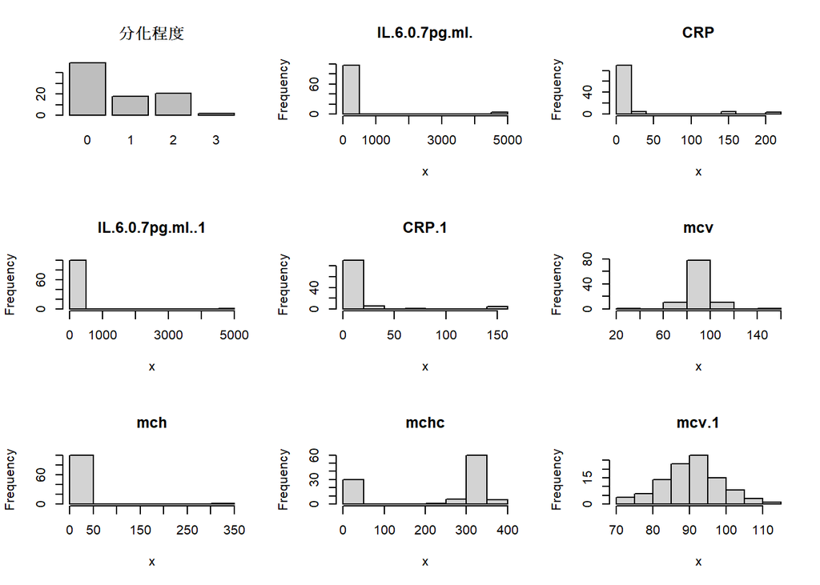

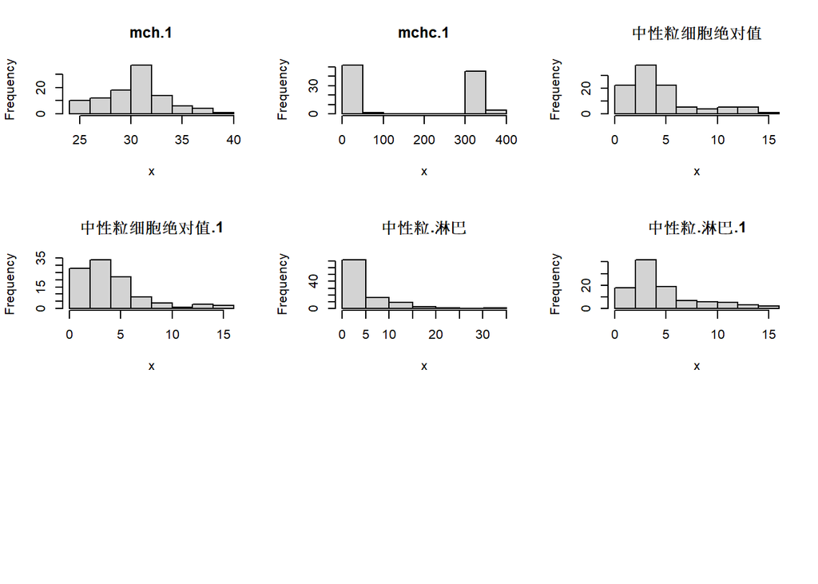

```r
par(mfrow=c(3,3))
plot_items_pattern(df_data_glm[,-1])
```

可以看到有很多变量是严重有偏的, 不适合直接扔进去, 把这些变量记下来, 然后mch有个离群值.

```r
df_data_glm %>% colnames()
```

```
##  [1] "姓名"               "淋巴细胞绝对值"     "淋巴细胞绝对值.1"
##  [4] "血红蛋白"           "血红蛋白.1"         "血红蛋白变化值"
##  [7] "贫血程度"           "贫血幅度是否改善"   "贫血幅度有否恶化"
## [10] "血红蛋白数值变化"   "血红蛋白是否改善"   "用药时间"
## [13] "年龄"               "性别"               "bmi"
## [16] "化疗有无"           "kps"                "确诊部位"
## [19] "病理类型"           "分化程度"           "IL.6.0.7pg.ml."
## [22] "CRP"                "IL.6.0.7pg.ml..1"   "CRP.1"
## [25] "mcv"                "mch"                "mchc"
## [28] "mcv.1"              "mch.1"              "mchc.1"
## [31] "中性粒细胞绝对值"   "中性粒细胞绝对值.1" "中性粒.淋巴"
## [34] "中性粒.淋巴.1"
```

先把mch的离群值拿走

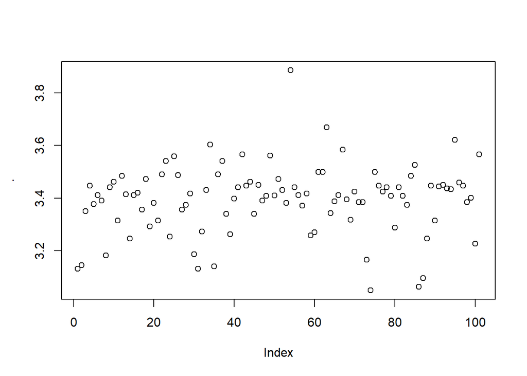

```r
# 第94个, 不是第108个
df_data_glm[-c(94), "mch"] %>% log() %>% plot()
```

```r
df_data_glm = df_data_glm[-c(94), ]
df_grpcop = df_grpcop[-c(94), ]
```

把有偏的数据变量, 捞出来

```r
var_skewed = c("IL.6.0.7pg.ml.", "CRP", "淋巴细胞绝对值", "IL.6.0.7pg.ml..1", "CRP.1", "淋巴细胞绝对值.1", "mch", "mchc", "mch.1", "mchc.1", "中性粒细胞绝对值", "中性粒细胞绝对值.1", "中性粒.淋巴", "中性粒.淋巴.1" )
```

看一下用来两两比较的数据框

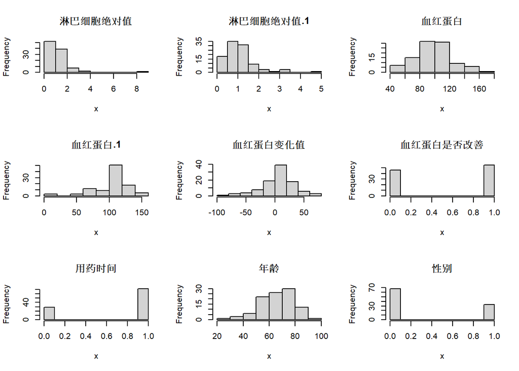

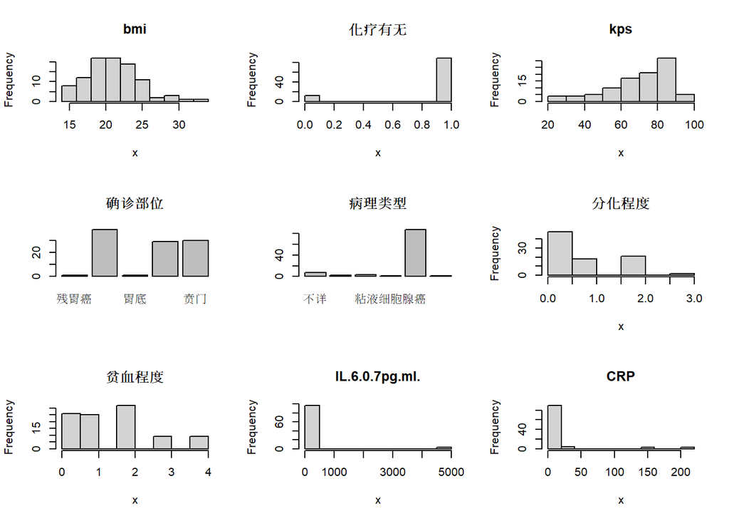

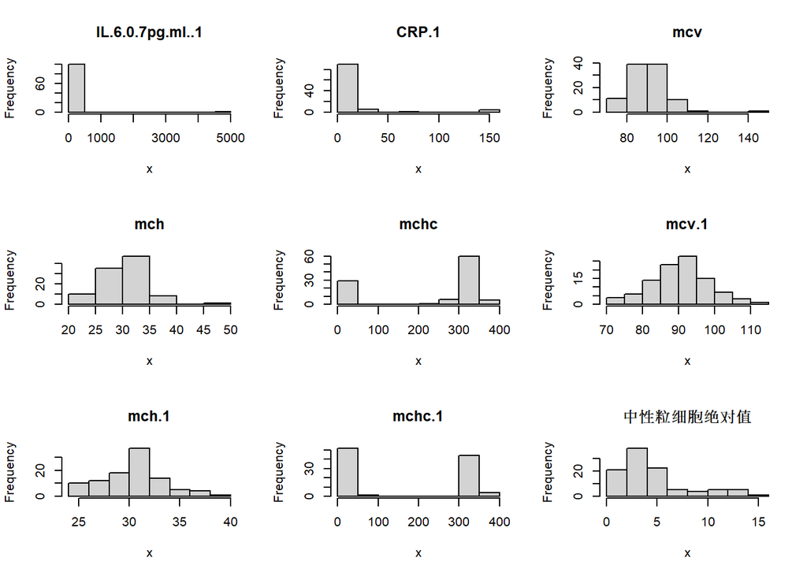

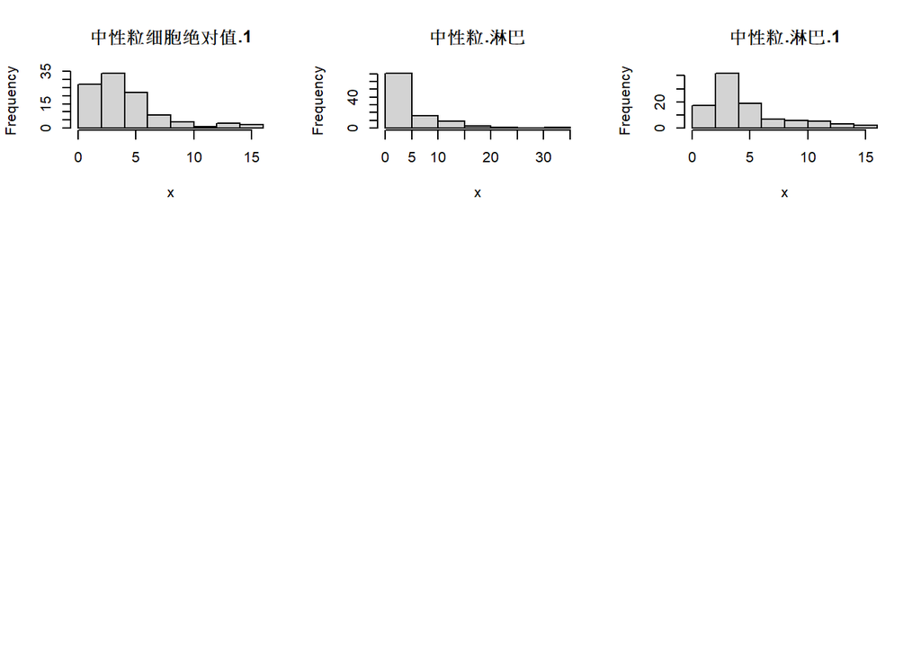

```r
par(mfrow=c(3,3))
df_grpcop[, -1] %>% plot_items_pattern
```

画一下原始数据的两两关系

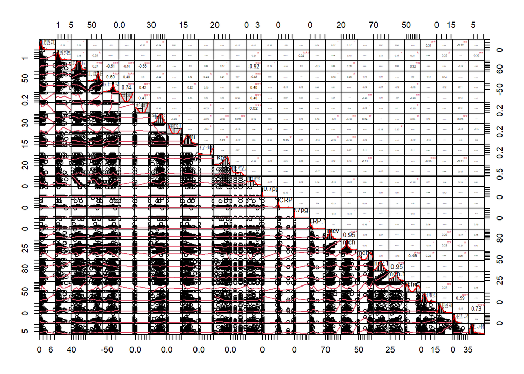

```r
# 把非数值的结果搞走
var_chr = c("姓名", "确诊部位", "病理类型")
chart.Correlation(df_grpcop[, !(colnames(df_grpcop) %in% var_chr)], histogram = TRUE, method = "pearson")
```

## 第二阶段: 做log转换尔后画pattern和两两对应的图

处理用于glm的数据

```r
df_data_glm[, colnames(df_data_glm) %in% var_skewed] =
  df_data_glm[, colnames(df_data_glm) %in% var_skewed] %>% log()
```

处理用于两两比较的数据

```r
df_grpcop[, colnames(df_grpcop) %in% var_skewed] =
  df_grpcop[, colnames(df_grpcop) %in% var_skewed] %>% log()
```

先画patterns

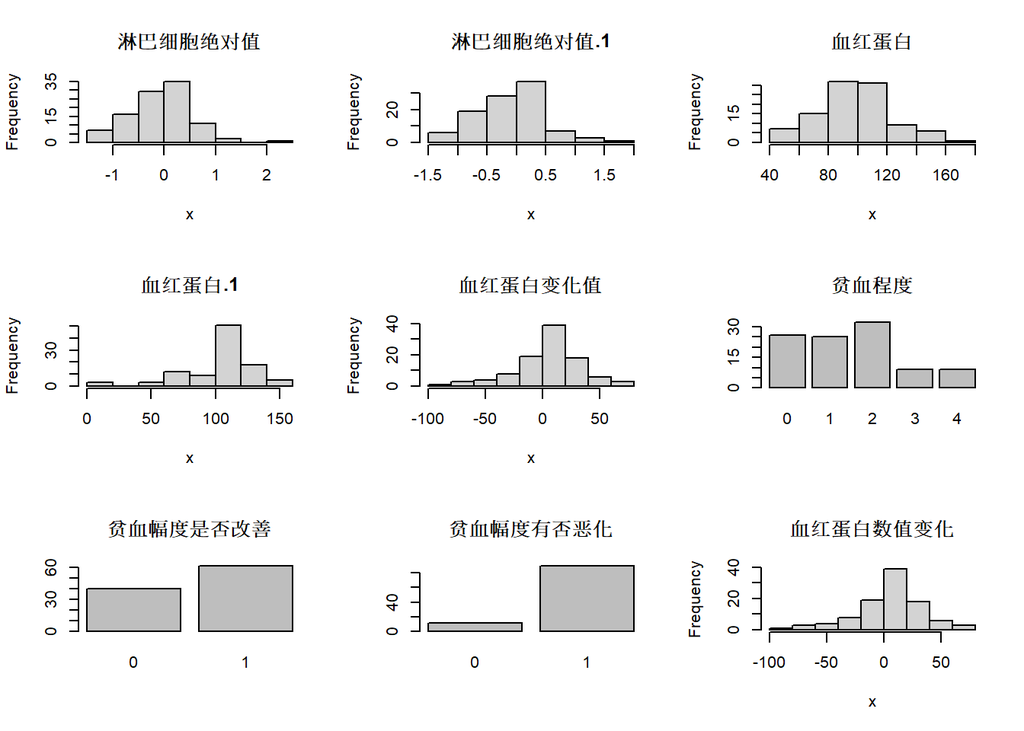

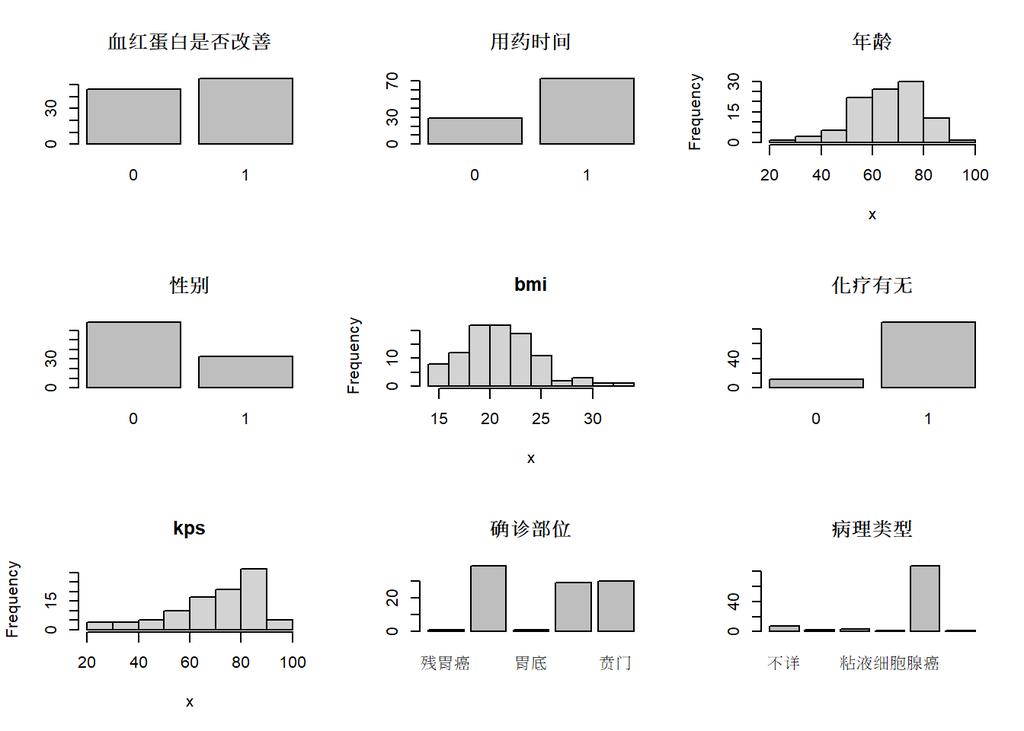

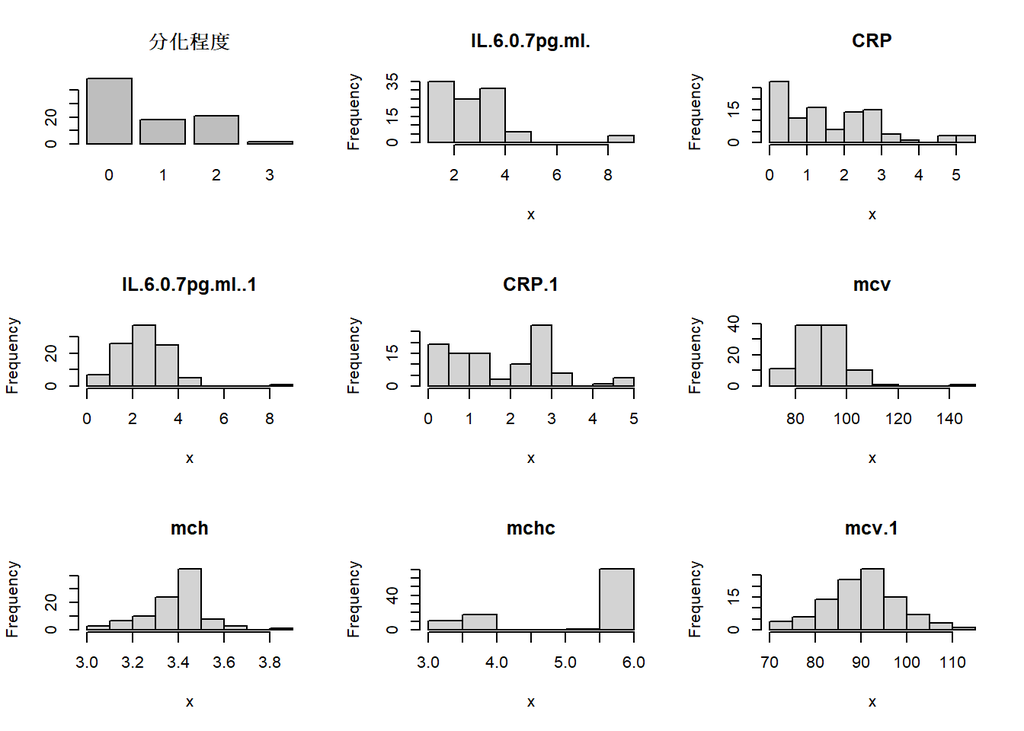

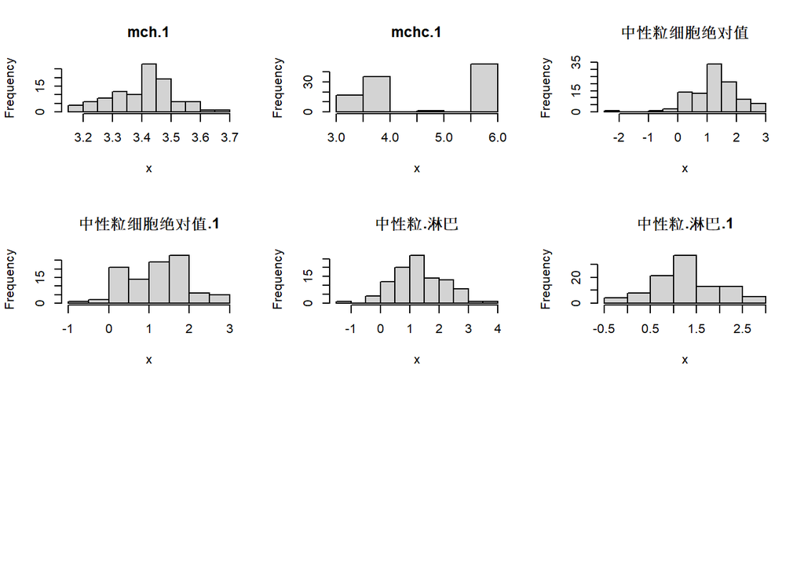

```r
par(mfrow=c(3,3))
df_data_glm[, -1] %>% plot_items_pattern()
```

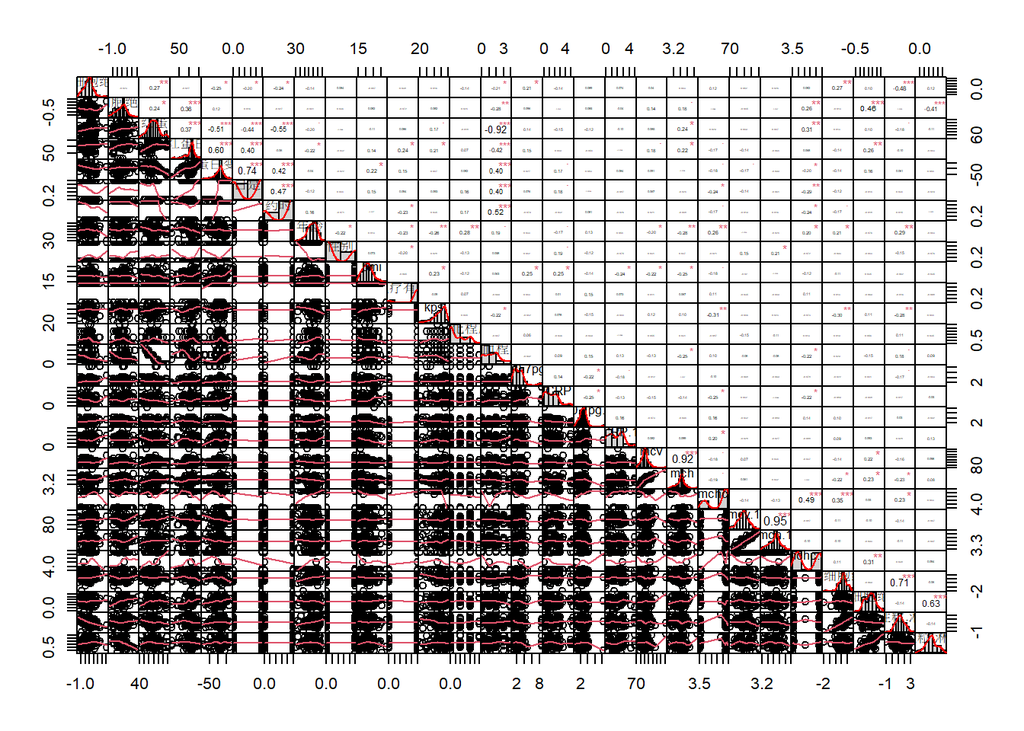

```r
chart.Correlation(df_grpcop[, !(colnames(df_grpcop) %in% var_chr)], histogram = TRUE, method = "pearson")
```

# 基线数据比较

比较改善与否的人, 他们的predictor是否有差异

```r
# compare_hemoglobin
compare_hemoglobin = twogrps(df_grpcop[,-1], "血红蛋白是否改善")
compare_hemoglobin$Table %>% print()
```

```
##
## 1                         Variables   Total (n = 101)           0 (n = 46)
## 2         淋巴细胞绝对值, Mean ± SD      -0.07 ± 0.61          0.06 ± 0.53
## 3       淋巴细胞绝对值.1, Mean ± SD       -0.11 ± 0.6         -0.12 ± 0.65
## 4               血红蛋白, Mean ± SD      99.7 ± 25.54       111.85 ± 27.35
## 5        血红蛋白.1, Median (Q1,Q3)     113 (99, 120)      107.5 (79, 116)
## 6    血红蛋白变化值, Median (Q1,Q3)       12 (-6, 22) -10.5 (-29.5, -0.25)
## 7                   用药时间, n (%)
## 8                                 0           29 (29)              24 (52)
## 9                                 1           72 (71)              22 (48)
## 10                  年龄, Mean ± SD     66.07 ± 12.85         67.78 ± 11.1
## 11                      性别, n (%)
## 12                                0           68 (67)              32 (70)
## 13                                1           33 (33)              14 (30)
## 14                   bmi, Mean ± SD      20.91 ± 3.66          20.3 ± 3.63
```

[output cut: 99 more lines]

```r
#

write.csv(compare_hemoglobin$table, "outputs/compare_hemoglobin.csv")
```

考虑以0.2为阈值, “用药时间”, “年龄”, “bmi”, “确诊部位”, “血红蛋白”, “IL.6.0.7pg.ml.”, “CRP”, “淋巴细胞绝对值”, “中性粒细胞绝对值”, “中性粒.淋巴”, “mchc”, “IL.6.0.7pg.ml..1”, “CRP.1”, “淋巴细胞绝对值.1”, “中性粒细胞绝对值.1”, “中性粒.淋巴.1”, “mchc.1”进行单因素分析.

# 单因素分析

## 单因素分析的一个具体案例: “血红蛋白是否改善” 与 “用药时间”

```r
#首先展示是否使用中药和贫血是否改善的一元 logistic 回归示例
#通过广义线性回归函数 glm() 执行 logistic 回归，详情 ?glm
#通过 family 参数指定了二项回归，即二分响应的 logistic 回归
fit_血红蛋白与用药 = glm(血红蛋白是否改善 ~ 用药时间, data = df_data_glm, family = binomial())

summary.glm(fit_血红蛋白与用药)  #展示拟合回归的简单统计
```

```
##
## Call:
## glm(formula = 血红蛋白是否改善 ~ 用药时间, family = binomial(),
##     data = df_data_glm)
##
## Deviance Residuals:
##     Min       1Q   Median       3Q      Max
## -1.5399  -0.6152   0.8540   0.8540   1.8750
##
## Coefficients:
##             Estimate Std. Error z value Pr(>|z|)
## (Intercept)  -1.5686     0.4916  -3.191  0.00142 **
## 用药时间1     2.3896     0.5542   4.312 1.62e-05 ***
## ---
## Signif. codes:  0 '***' 0.001 '**' 0.01 '*' 0.05 '.' 0.1 ' ' 1
##
## (Dispersion parameter for binomial family taken to be 1)
##
##     Null deviance: 139.21  on 100  degrees of freedom
## Residual deviance: 115.29  on  99  degrees of freedom
## AIC: 119.29
##
## Number of Fisher Scoring iterations: 4
```

为了将回归系数作为比率比给出,

需要写一个读取的辅助函数

```r
get_glm_OR = function(fit_single_model, row_var=2) {
  # 参数:
  # fit_single_model: glm模型
  # row_var: 第几个回归变量, 1为截距, 再单因素分析里面, 2为需要分析的因素
  # 返回:
  # 一个vector, 有四个列, 第一列OR的点估计, 第二列是区间下限(2.5%), 第三列是
  # 区间上限(97,5%), 第四列是p值
  vec_coef_p = coefficients(summary.glm(fit_single_model))[row_var, c(1,4)]
  vec_cofint = confint(fit_single_model)[row_var,]
  vec_est = c(vec_coef_p[1], vec_cofint, vec_coef_p[2])
  vec_est[1:3] = exp(vec_est[1:3])
  # vec_est = format(vec_est, scientific = FALSE, digits = 1)
  # vec_est = as.numeric(vec_est)
  return(vec_est)
}

# debug
vec_用药 = get_glm_OR(fit_血红蛋白与用药)
vec_用药 %>% print()
```

```
##     Estimate        2.5 %       97.5 %     Pr(>|z|)
## 1.090909e+01 3.941662e+00 3.585372e+01 1.618502e-05
```

尝试写一个for循环来解决问题

```r
var_单因素 = c("用药时间", "年龄", "bmi", "血红蛋白", "IL.6.0.7pg.ml.", "CRP", "淋巴细胞绝对值", "中性粒细胞绝对值", "中性粒.淋巴", "mchc", "IL.6.0.7pg.ml..1", "CRP.1", "淋巴细胞绝对值.1", "中性粒细胞绝对值.1", "中性粒.淋巴.1", "mchc.1")
```

```r
df_data_glm[, var_单因素] %>% head()
```

```
##   用药时间 年龄      bmi 血红蛋白 IL.6.0.7pg.ml.        CRP 淋巴细胞绝对值
## 1        1   79 25.24934       71       1.396245 0.07696104     -0.1743534
## 2        1   84 21.75020       78       2.052841 1.38629436      0.6418539
## 3        1   81 14.69238       98       4.123903 2.82137889      0.1043600
## 4        0   73 15.54895      127       1.887070 0.23111172      0.6043160
## 5        1   69 21.57738      126       3.444257 0.00000000      0.5653138
## 6        1   70 25.24934       67       2.870169 3.03013370     -1.2039728
##   中性粒细胞绝对值 中性粒.淋巴     mchc IL.6.0.7pg.ml..1     CRP.1
## 1         1.396245   1.5705981 5.676754         8.517193 1.7833912
## 2         1.223775   0.5819215 5.733341         3.195402 2.9755296
## 3         2.547099   2.4427387 5.802118         2.309561 0.6931472
## 4         2.249184   1.6448683 5.826000         2.701361 2.2721259
## 5         1.501853   0.9365389 5.783825         2.644755 0.0000000
## 6         1.335001   2.5389739 5.826000         1.699279 0.6931472
##   淋巴细胞绝对值.1 中性粒细胞绝对值.1 中性粒.淋巴.1   mchc.1
## 1       1.25276297           1.280934    0.02817088 5.789960
## 2       0.45107562           1.930071    1.47899547 5.817111
## 3       0.19885086           1.018847    0.81999646 5.826000
## 4       1.58514522           1.877937    0.29279195 5.886104
## 5       0.07696104           1.081805    1.00484413 5.820083
## 6       0.74193734           1.526056    0.78411896 5.780744
```

```r
# lapply(1:30, function(i) glm(as.formula(paste0('casecontrol ~ ', 'rs', i)), data = mydata, family = binomial))

l_单因素回归 =
  lapply(var_单因素,
         function(i) glm(as.formula(paste('血红蛋白是否改善 ~ ', i)), data = df_data_glm, family = binomial))
```

读取并保存单因素回归结果的OR点估计和区间估计, 还有p值

```r
result_OR_name = c("OR", "2.5 %", "97.5 %", "Pr(>|z|)")
result_OR = vector()

for (j in 1:length(var_单因素)) {
  result_OR = rbind(result_OR, get_glm_OR(l_单因素回归[[j]]))
}

rownames(result_OR) = var_单因素
result_OR %>% as.data.frame() %>% print()
```

```
##                      Estimate     2.5 %     97.5 %     Pr(>|z|)
## 用药时间           10.9090909 3.9416625 35.8537241 1.618502e-05
## 年龄                0.9805322 0.9490520  1.0113769 2.215221e-01
## bmi                 1.0924119 0.9787337  1.2289780 1.247031e-01
## 血红蛋白            0.9573365 0.9347819  0.9767276 8.653520e-05
## IL.6.0.7pg.ml.      1.1097436 0.8552059  1.4813710 4.463368e-01
## CRP                 1.3108185 0.9813402  1.7939951 7.612272e-02
## 淋巴细胞绝对值      0.5016495 0.2415001  0.9801140 5.129318e-02
## 中性粒细胞绝对值    0.7161654 0.4063431  1.2120252 2.262432e-01
## 中性粒.淋巴         1.0850759 0.6772297  1.7500536 7.336372e-01
## mchc                0.6024807 0.3889357  0.8994208 1.669351e-02
## IL.6.0.7pg.ml..1    1.0002475 0.6969516  1.4413681 9.989055e-01
## CRP.1               0.8752938 0.6443588  1.1804094 3.846958e-01
## 淋巴细胞绝对值.1    1.0557579 0.5424501  2.0630491 8.722796e-01
## 中性粒细胞绝对值.1  0.9595624 0.5417046  1.6954215 8.862993e-01
## 中性粒.淋巴.1       0.9183461 0.5097433  1.6448461 7.737003e-01
## mchc.1              0.5897281 0.4086529  0.8387345 3.855710e-03
```

把结果保存下来

```r
write.csv(result_OR, "outputs/result_OR.csv")
```

以0.25为阈值找出纳入多因素分析的变量

```r
rownames(result_OR)[result_OR[, 4]<0.25]
```

```
## [1] "用药时间"         "年龄"             "bmi"              "血红蛋白"
## [5] "CRP"              "淋巴细胞绝对值"   "中性粒细胞绝对值" "mchc"
## [9] "mchc.1"
```

## 多因素分析

留意到贫血程度和用药时间有交互, 因此, 首先是没交互的, 尔后搞个有交互的

### 没交互的多因素模型

```r
fit_多因素_1 =
  glm(血红蛋白是否改善 ~ 用药时间 + 年龄 + bmi + 血红蛋白 + CRP + 淋巴细胞绝对值 + mchc,
    data = df_data_glm, family = binomial())

summary.glm(fit_多因素_1)  #展示拟合回归的简单统计
```

```
##
## Call:
## glm(formula = 血红蛋白是否改善 ~ 用药时间 + 年龄 +
##     bmi + 血红蛋白 + CRP + 淋巴细胞绝对值 + mchc,
##     family = binomial(), data = df_data_glm)
##
## Deviance Residuals:
##     Min       1Q   Median       3Q      Max
## -2.2191  -0.5980   0.3558   0.7806   2.3038
##
## Coefficients:
##                Estimate Std. Error z value Pr(>|z|)
## (Intercept)     3.91835    3.23843   1.210  0.22630
## 用药时间1       2.18361    0.76986   2.836  0.00456 **
## 年龄           -0.04705    0.02277  -2.067  0.03877 *
## bmi             0.09243    0.07751   1.192  0.23307
## 血红蛋白       -0.03109    0.01391  -2.235  0.02543 *
## CRP             0.19332    0.20678   0.935  0.34984
## 淋巴细胞绝对值 -0.24965    0.42925  -0.582  0.56084
## mchc           -0.27089    0.26657  -1.016  0.30953
## ---
## Signif. codes:  0 '***' 0.001 '**' 0.01 '*' 0.05 '.' 0.1 ' ' 1
##
## (Dispersion parameter for binomial family taken to be 1)
##
##     Null deviance: 139.213  on 100  degrees of freedom
## Residual deviance:  96.232  on  93  degrees of freedom
## AIC: 112.23
##
## Number of Fisher Scoring iterations: 5
```

回归系数作为比率比给出

```r
fit_多因素_1 %>% coef %>% exp() %>% print()
```

```
##    (Intercept)      用药时间1           年龄            bmi       血红蛋白
##     50.3172445      8.8782770      0.9540419      1.0968315      0.9693909
##            CRP 淋巴细胞绝对值           mchc
##      1.2132696      0.7790731      0.7626990
```

```r
fit_多因素_1 %>% confint() %>% exp() %>% print()
```

```
##                     2.5 %       97.5 %
## (Intercept)    0.09098999 3.497556e+04
## 用药时间1      2.13591872 4.574554e+01
## 年龄           0.90917317 9.950508e-01
## bmi            0.94654591 1.285728e+00
## 血红蛋白       0.94126184 9.946469e-01
## CRP            0.81066208 1.837208e+00
## 淋巴细胞绝对值 0.32712447 1.809428e+00
## mchc           0.44485173 1.279518e+00
```

### 用药时间和贫血程度交互的多因素模型

```r
fit_多因素_2 =
  glm(血红蛋白是否改善 ~ 用药时间 * 血红蛋白 + 年龄 + bmi + CRP + 淋巴细胞绝对值 + mchc,
    data = df_data_glm, family = binomial())

summary.glm(fit_多因素_2)  #展示拟合回归的简单统计
```

```
##
## Call:
## glm(formula = 血红蛋白是否改善 ~ 用药时间 * 血红蛋白 +
##     年龄 + bmi + CRP + 淋巴细胞绝对值 + mchc, family = binomial(),
##     data = df_data_glm)
##
## Deviance Residuals:
##     Min       1Q   Median       3Q      Max
## -2.1604  -0.7341   0.3840   0.7567   2.3611
##
## Coefficients:
##                    Estimate Std. Error z value Pr(>|z|)
## (Intercept)         8.03597    4.95197   1.623   0.1046
## 用药时间1          -2.96423    4.35674  -0.680   0.4963
## 血红蛋白           -0.07089    0.03851  -1.841   0.0657 .
## 年龄               -0.04563    0.02263  -2.017   0.0437 *
## bmi                 0.09116    0.08166   1.116   0.2643
## CRP                 0.19807    0.21037   0.942   0.3464
## 淋巴细胞绝对值     -0.31608    0.43228  -0.731   0.4647
## mchc               -0.24743    0.27002  -0.916   0.3595
## 用药时间1:血红蛋白  0.04870    0.04115   1.184   0.2366
## ---
## Signif. codes:  0 '***' 0.001 '**' 0.01 '*' 0.05 '.' 0.1 ' ' 1
##
## (Dispersion parameter for binomial family taken to be 1)
##
##     Null deviance: 139.213  on 100  degrees of freedom
## Residual deviance:  94.543  on  92  degrees of freedom
## AIC: 112.54
##
## Number of Fisher Scoring iterations: 6
```

回归系数作为比率比给出

```r
fit_多因素_2 %>% coef %>% exp() %>% print()
```

```
##        (Intercept)          用药时间1           血红蛋白               年龄
##       3.090131e+03       5.160003e-02       9.315638e-01       9.553981e-01
##                bmi                CRP     淋巴细胞绝对值               mchc
##       1.095441e+00       1.219051e+00       7.290007e-01       7.808011e-01
## 用药时间1:血红蛋白
##       1.049903e+00
```

```r
fit_多因素_2 %>% confint() %>% exp() %>% print()
```

```
##                           2.5 %       97.5 %
## (Intercept)        4.462461e-01 1.979861e+08
## 用药时间1          2.284098e-06 1.164670e+02
## 血红蛋白           8.488776e-01 9.921250e-01
## 年龄               9.107253e-01 9.962666e-01
## bmi                9.390665e-01 1.297268e+00
## CRP                8.102698e-01 1.863399e+00
## 淋巴细胞绝对值     3.031084e-01 1.698538e+00
## mchc               4.508623e-01 1.315889e+00
## 用药时间1:血红蛋白 9.781138e-01 1.155851e+00
```

## 随机森林模型

把na拿掉

```r
df_data_rf = df_data_glm[!(is.na(df_data_glm[, '血红蛋白是否改善'])), ]
```

```r
#随机森林计算（默认生成 500 棵决策树），详情 ?randomForest
set.seed(123)
rf_多因素 =
  randomForest(血红蛋白是否改善 ~ 用药时间 + 年龄 + bmi + 血红蛋白 + CRP + 淋巴细胞绝对值 + mchc, data = df_data_rf, importance = TRUE)

rf_多因素
```

```
##
## Call:
##  randomForest(formula = 血红蛋白是否改善 ~ 用药时间 +      年龄 + bmi + 血红蛋白 + CRP + 淋巴细胞绝对值 +      mchc, data = df_data_rf, importance = TRUE)
##                Type of random forest: classification
##                      Number of trees: 500
## No. of variables tried at each split: 2
##
##         OOB estimate of  error rate: 25.74%
## Confusion matrix:
##    0  1 class.error
## 0 30 16   0.3478261
## 1 10 45   0.1818182
```

```r
importance_rf_多因素 = rf_多因素$importance
head(importance_rf_多因素)
```

```
##                           0            1 MeanDecreaseAccuracy MeanDecreaseGini
## 用药时间        0.057971256  0.045796272         0.0507712836         5.480713
## 年龄            0.005281454 -0.003319358         0.0001377445         5.544005
## bmi            -0.005031664  0.008241784         0.0023357121         6.604073
## 血红蛋白        0.066776184  0.072737423         0.0693442178        13.156320
## CRP            -0.003341750 -0.007987700        -0.0057530610         4.231367
## 淋巴细胞绝对值  0.004741894  0.016684955         0.0115899464         6.461229
```

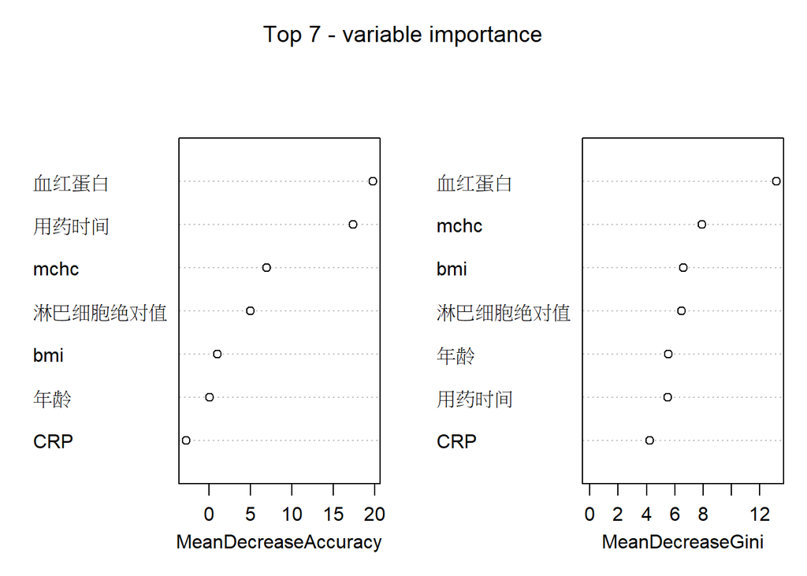

```r
varImpPlot(rf_多因素, n.var = min(7, nrow(rf_多因素$importance)),
    main = 'Top 7 - variable importance')
```

## 混合效应模型

有两个重复测量的结果, 即CRP和mchc, 考虑引入混合效应模型.

基线的数据是固定效应, CRP和mchc有随机效应